# Tenth Week: Cluster Analysis

WDI Indicators

Shabnam Sheikhha (95105679)

2018-07-14 21:39:21

> I haven’t included the code for some of the parts in order to keep this document as neat as I can.

# 1 Poorest Countries

## 1.1 Top 10 Poorest Countries

> Indicator used : GDP per capita, PPP

| country | AVG.GDP |
| --- | --- |
| Congo, Dem. Rep. | 577.9251 |
| Mozambique | 633.0980 |
| Liberia | 663.2484 |
| Burundi | 693.9625 |
| Central African Republic | 697.5407 |
| Niger | 701.4817 |
| Ethiopia | 762.7194 |
| Malawi | 784.3213 |
| Rwanda | 965.3107 |
| Sierra Leone | 991.0150 |

### 1.1.1 Daily Income

> Indicator used : Secondary income

[interactive chart not shown]

### 1.1.2 Percentage Below Poverty Line

> Indicator used : Poverty headcount ratio at national poverty lines

| country | AVG.GDP | below.line.perc |
| --- | --- | --- |
| Congo, Dem. Rep. | 577.9251 | 66.60000 |
| Mozambique | 633.0980 | 56.07500 |
| Liberia | 663.2484 | 58.95000 |
| Burundi | 693.9625 | 66.00000 |
| Central African Republic | 697.5407 | 62.00000 |
| Niger | 701.4817 | 46.70000 |
| Ethiopia | 762.7194 | 39.55000 |
| Malawi | 784.3213 | 56.13333 |
| Rwanda | 965.3107 | 50.17500 |
| Sierra Leone | 991.0150 | 59.65000 |

### 1.1.3 Life Expectancy

> Indicator used : Life expectancy at birth

| country | AVG.GDP | life.expectancy |
| --- | --- | --- |
| Congo, Dem. Rep. | 577.9251 | 48.79504 |
| Mozambique | 633.0980 | 44.88063 |
| Liberia | 663.2484 | 47.94842 |
| Burundi | 693.9625 | 48.65196 |
| Central African Republic | 697.5407 | 45.55235 |
| Niger | 701.4817 | 44.48879 |
| Ethiopia | 762.7194 | 48.95458 |
| Malawi | 784.3213 | 46.71595 |
| Rwanda | 965.3107 | 47.70888 |
| Sierra Leone | 991.0150 | 39.34898 |

# 2 Rwanda Tragedy

## 2.1 Life Expectancy Boxplot

We’ve downloaded this data in the previous section.

[interactive chart not shown]

As you can see, there is a drastic drop in the year 1993. This is a clear visual demonstration of the Rwanda tragedy.

## 2.2 Number of People Who Died

Out of a population of 7.3 million people, the official figures published by the Rwandan government estimated the number of victims of the genocide to be 1,070,014 in only 100 days. [Wikipedia](https://en.wikipedia.org/wiki/Rwandan_genocide)

> Indicator used : Population, total

As we can see the population has decreased significantly between the year 1992 and 1993. The data does not match the one from the wikipedia page exactly, but this might be due to the fact that the values in the dataset are midyear estimates.

| country | year | SP.POP.TOTL |
| --- | --- | --- |
| Rwanda | 1992 | 6701851 |
| Rwanda | 1993 | 6299909 |
| Rwanda | 1994 | 6005095 |
| Rwanda | 1995 | 5928078 |

# 3 Life Expectancy Vs. Health Expenditure

> Indicator Used for Health Expenditure: Current health expenditure per capita

> Indicator Used for Life Expectancy: Life expectancy at birth

We’ve downloaded this data before.

Before drawing any plots, it’s logical to suspect that health expenditure has a positive effect on life expectancy.  
To test whether this is true or not, first I’ve drawn the plot.

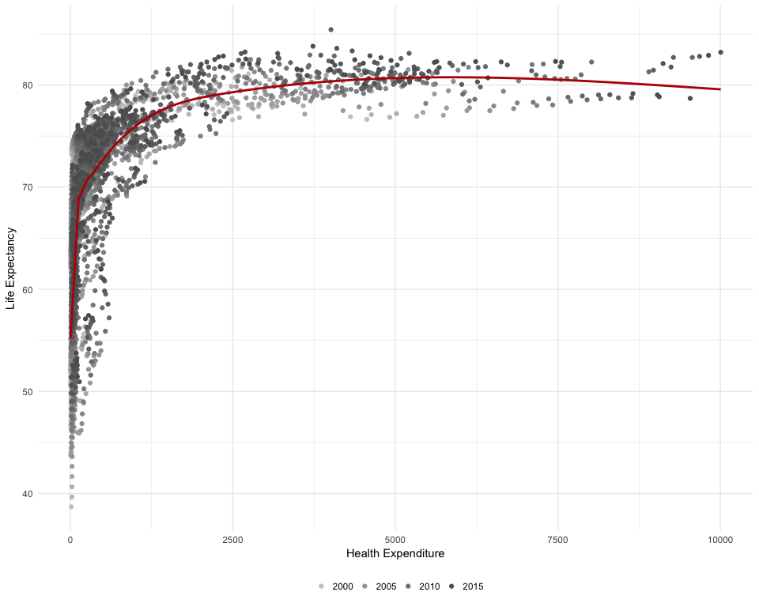

The plot seems to show a positive relationship between the two. I’ve also tested the correlation using `cor.test()`

```r
cor.test(hl$`Health Expenditure`, hl$`Life Expectancy`)
```

```
    Pearson's product-moment correlation

data:  hl$`Health Expenditure` and hl$`Life Expectancy`
t = 39.479, df = 3584, p-value < 2.2e-16
alternative hypothesis: true correlation is not equal to 0
95 percent confidence interval:
 0.5272897 0.5729279
sample estimates:
    cor
0.55052
```

Since the $p-value$ is low, we can conclude that there is a positive correlation between health expenditure and life expectancy.

# 4 Iranian Households in The Past 50 Years

> Indicator used: GDP per capita

[interactive chart not shown]

As we can see, in general it’s increasing.

# 5 Economic Indicators

First I have written a function that takes in these parameters:

1. A Source Data Frame containing columns named `indicator`, `year` and `country`.
2. The Chart Title
3. The Y Axis Name
4. A Color Specifying Iran

and draws the desired plot.

## 5.1 Cleaning The Dataset

Some of the countries in the dataset have titles such as **Low Income** or **Arab World**, etc. I looked at the `countries` dataset, and realized that tha `Region` column for these particular non-countries, was NA. So I’ve deleted those rows from the dataset.

```r
keep <- countries %>% filter(!is.na(Region)) %>% select(`Country Code`) %>% unlist() %>% unname()
data <- data %>% filter(`Country Code` %in% keep)
```

## 5.2 Choosing The Indicators

Since many of the indicators didn’t have as many as 20 years worth of data available for Iran, I have opted for those who had at least 16 between the years 1995 and 2015.

[interactive chart not shown]

# 6 Clustering Based on Economic Data

## 6.1 Removing NAs

```r
all.econ.clusters <- all.econ %>% drop_na()
```

## 6.2 Cluster Analysis by K-means

```r
all.econ.clusters <- all.econ.clusters %>%
  dplyr::select(-year) %>%
  dplyr::group_by(country) %>%
  dplyr::summarise_all(funs(mean))
```

```r
kcl.econ <- kmeans(all.econ.clusters %>% dplyr::select(-country), centers = 3)
all.econ.clusters$cluster <- kcl.econ$cluster
kcl.econ
```

```
K-means clustering with 3 clusters of sizes 10, 3, 88

Cluster means:
  Exports of goods and services Imports of goods and services
1                      28.71021                      25.70171
2                      16.67121                      16.34138
3                      40.02531                      43.35328
  Adjusted savings: education expenditure Inflation, consumer prices
1                                4.405205                   5.653639
2                                3.177420                   1.775061
3                                3.946314                  55.770108
  GDP per capita Gross capital formation Agriculture Value added
1      18586.036                25.76114                6.072671
2      28429.630                29.28776                5.105043
3       7626.631                23.82589               13.954913
  Access to electricity    Trade Gross domestic savings
1              95.63988 54.41192               28.76964
2              99.19167 33.01258               29.62422
3              78.50730 83.37859               20.50536
  Unemployment, total Manufacturing, value added Energy imports, net
1            5.592702               1.595023e+11           -52.87524
2            4.905592               1.299907e+12            37.19254
3            9.295295               1.293524e+10           -46.72084
  Broad money Foreign direct investment Industry, value added
1    71.95184               37946027528          3.363419e+11
2   147.24449              124411101288          1.962530e+12
3    49.65934                2756949036          2.806723e+10
  Military expenditure GNI per capita, Atlas method
1             2.561686                    17845.460
2             2.181872                    29139.940
3             2.148475                     7368.645
  Personal remittances, received Services, etc., value added
1                     7627506012                    58.72863
2                     4686689917                    62.24501
3                     1692702956                    52.57777

Clustering vector:
  [1] 3 3 3 3 3 1 3 3 3 3 3 3 1 3 3 3 1 3 2 3 3 3 3 3 3 3 3 3 3 3 3 3 3 3 3
 [36] 3 3 1 1 3 3 3 3 2 3 3 3 1 3 3 3 3 3 3 3 1 3 3 3 3 3 3 3 3 3 3 3 3 3 3
 [71] 3 3 3 3 3 3 1 1 3 3 3 3 3 3 3 3 3 3 3 3 3 3 3 3 1 2 3 3 3 3 3

Within cluster sum of squares by cluster:
[1] 9.398915e+22 1.258178e+24 1.496682e+23
 (between_SS / total_SS =  91.6 %)

Available components:

[1] "cluster"      "centers"      "totss"        "withinss"
[5] "tot.withinss" "betweenss"    "size"         "iter"
[9] "ifault"
```

## 6.3 Iran’s cluster

```r
iran.econ.cluster <- all.econ.clusters %>% dplyr::filter(country %>% str_detect("Iran"))
all.econ.clusters %>% dplyr::select(country, cluster) %>% dplyr::filter(cluster == iran.econ.cluster$cluster) %>%
  knitr::kable(format = "html") %>% kable_styling(bootstrap_options = c("striped", "hover"), full_width = F, position = "left")
```

| country | cluster |
| --- | --- |
| Albania | 3 |
| Algeria | 3 |
| Angola | 3 |
| Argentina | 3 |
| Armenia | 3 |
| Azerbaijan | 3 |
| Bangladesh | 3 |
| Belarus | 3 |
| Benin | 3 |
| Bolivia | 3 |
| Botswana | 3 |
| Bulgaria | 3 |
| Cambodia | 3 |
| Cameroon | 3 |
| Chile | 3 |
| Colombia | 3 |
| Congo, Dem. Rep. | 3 |
| Congo, Rep. | 3 |
| Cote d’Ivoire | 3 |
| Croatia | 3 |
| Czech Republic | 3 |
| Denmark | 3 |
| Dominican Republic | 3 |
| Ecuador | 3 |
| Egypt, Arab Rep. | 3 |
| El Salvador | 3 |
| Gabon | 3 |
| Georgia | 3 |
| Ghana | 3 |
| Guatemala | 3 |

[output cut: 58 more lines]

# 7 Evaluating The Cluster Using PCA Biplot

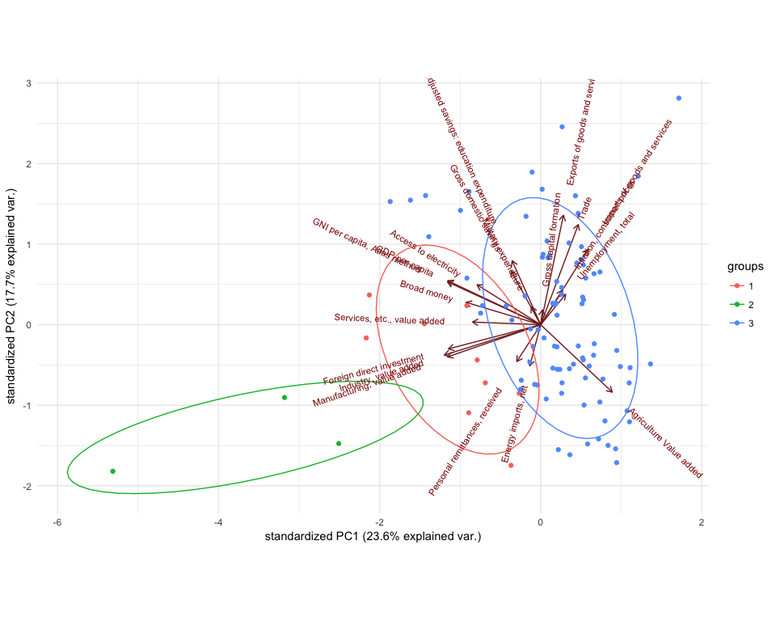

```r
econ.cluster.pca = prcomp(all.econ.clusters %>% dplyr::select(-country, -cluster), center = T, scale. = T)
biplot <- ggbiplot(econ.cluster.pca,
         groups = as.factor(kcl.econ$cluster), ellipse = T) +
  theme_minimal()
biplot
```

After drawing the biplot we see that the groups are more or less distinct. Also the countries in each cluster seem to make sense. Most first world countries ended up in the same group, and most third world countries ended up in a different group from them.  
# Predicting Economic Growth

> Indicator used: GDP growth

```r
growth <- data %>% filter(`Indicator Code` == "NY.GDP.MKTP.KD.ZG")
growth <- growth %>%
  gather(key = "year", value = "NY.GDP.MKTP.KD.ZG", 5:(ncol(growth) - 1)) %>%
  select(country = `Country Name`, year, indicator = NY.GDP.MKTP.KD.ZG) %>% drop_na() %>%
  filter(year >= 1995 & year <= 2015)
growth <- growth %>% plyr::rename(c("indicator" = "GDP growth"))

all.econ.growth <- all.econ %>% full_join(growth)
all.econ.growth <- all.econ.growth %>% dplyr::select(-country) %>% sapply(as.numeric) %>% na.aggregate() %>% as.data.frame()
all.econ.growth$country <- all.econ$country
iran.econ.growth <- all.econ.growth %>% dplyr::filter(country %>% str_detect("Iran"))
```

```r
library(h2o)
h2o.init()
```

```
 Connection successful!

R is connected to the H2O cluster:
    H2O cluster uptime:         10 hours 38 minutes
    H2O cluster timezone:       Asia/Tehran
    H2O data parsing timezone:  UTC
    H2O cluster version:        3.20.0.2
    H2O cluster version age:    29 days
    H2O cluster name:           H2O_started_from_R_deyapple_ofd783
    H2O cluster total nodes:    1
    H2O cluster total memory:   1.61 GB
    H2O cluster total cores:    4
    H2O cluster allowed cores:  4
    H2O cluster healthy:        TRUE
    H2O Connection ip:          localhost
    H2O Connection port:        54321
    H2O Connection proxy:       NA
    H2O Internal Security:      FALSE
    H2O API Extensions:         XGBoost, Algos, AutoML, Core V3, Core V4
    R Version:                  R version 3.4.3 (2017-11-30)
```

```r
hiran = as.h2o(iran.econ.growth %>% dplyr::select(-year, -country, `GDP growth`))
iglm <- h2o.glm(training_frame = hiran,
        y = "GDP growth",
        x = iran.econ.growth %>% dplyr::select(-year, -country, -`GDP growth`) %>% colnames(),
        family = "gaussian")
iglm
```

```
Model Details:
==============

H2ORegressionModel: glm
Model ID:  GLM_model_R_1531549845396_10
GLM Model: summary
    family     link                              regularization
1 gaussian identity Elastic Net (alpha = 0.5, lambda = 0.3717 )
  number_of_predictors_total number_of_active_predictors
1                         20                          10
  number_of_iterations              training_frame
1                    1 file10ef589d59bd_sid_a189_2

Coefficients: glm coefficients
                                    names coefficients
1                               Intercept     9.148402
2           Exports of goods and services     0.027062
3           Imports of goods and services     0.000000
4 Adjusted savings: education expenditure     1.211471
5              Inflation, consumer prices    -0.107659
  standardized_coefficients
1                  3.103266
2                  0.116513
3                  0.000000
4                  0.763217
5                 -1.051437

---
                            names coefficients standardized_coefficients
16      Foreign direct investment     0.000000                  0.000000
17          Industry, value added    -0.000000                 -0.115709
18           Military expenditure    -3.599073                 -1.073709
19   GNI per capita, Atlas method     0.000000                  0.000000
20 Personal remittances, received     0.000000                  0.000000
21    Services, etc., value added    -0.125915                 -0.402402

H2ORegressionMetrics: glm
** Reported on training data. **

MSE:  3.938588
RMSE:  1.984588
MAE:  1.524596
RMSLE:  NaN
Mean Residual Deviance :  3.938588
R^2 :  0.6985792
Null Deviance :274.4016
Null D.o.F. :20
Residual Deviance :82.71036
Residual D.o.F. :10
AIC :112.3827
```

# 8 Health and Education Indicators

## 8.1 Health

### 8.1.1 Q5

[interactive chart not shown]

### 8.1.2 Health Cluster Analysis Using K-Means

#### 8.1.2.1 Replacing NAs

This time too, I have replaces NAs with the mean.

```r
all.health.clusters <- all.health %>% dplyr::select(-country) %>% sapply(as.numeric) %>% na.aggregate() %>% as.data.frame()
all.health.clusters$country <- all.health$country

all.health.clusters <- all.health.clusters %>%
  dplyr::select(-year) %>%
  dplyr::group_by(country) %>%
  dplyr::summarise_all(funs(mean))
```

#### 8.1.2.2 Cluster Analysis by K-means

```r
kcl.health <- kmeans(all.health.clusters %>% dplyr::select(-country), centers = 3)
kcl.health
```

```
K-means clustering with 3 clusters of sizes 126, 31, 60

Cluster means:
  Birth rate, crude Death rate, crude Fertility rate, total
1          17.42610          7.516925              2.287721
2          40.40955         12.087608              5.220733
3          25.84597          8.205383              3.344955
  Immunization, DPT Survival to age 65, male
1          90.98635                 73.71012
2          71.21760                 47.60288
3          83.12225                 61.96089
  Life expectancy at birth, total Population growth
1                        73.90612          1.112618
2                        56.14704          2.579718
3                        66.72220          1.523247
  Prevalence of anemia among children Survival to age 65, female
1                            28.34329                   83.77539
2                            61.71491                   54.01182
3                            46.08913                   70.45725
  Age dependency ratio Mortality rate, under-5 Maternal mortality ratio
1             54.01232                22.79170                 85.23586
2             86.99161               110.51270                683.63539
3             67.44975                54.72529                271.22778
  Mortality rate, neonatal Immunization, measles
1                 10.69070              90.45599
2                 33.67130              70.72553
3                 21.72721              81.85413
  Lifetime risk of maternal death Mortality rate, adult, female
1                        0.352467                      100.6010
2                        3.818525                      315.0152
3                        1.262610                      190.1301
  Mortality rate, adult, male Mortality rate, infant Immunization, HepB3
1                    174.3107               17.96468            87.26559
2                    367.7714               70.36106            80.33579
3                    254.9389               39.13585            84.04885
  Depth of the food deficit
1                  104.0168
2                  176.2589
3                  149.6515

Clustering vector:
  [1] 2 1 1 3 3 2 3 1 1 1 1 1 1 1 1 3 1 1 1 1 3 3 3 3 1 3 1 3 1 1 3 2 1 3 2
 [36] 1 3 2 2 1 1 1 1 3 2 2 1 2 1 1 1 1 1 1 3 3 1 1 1 1 3 2 1 2 3 1 1 1 3 3
 [71] 2 1 1 3 3 1 3 1 1 1 2 2 3 3 1 1 1 1 3 3 1 1 1 3 1 1 1 1 1 1 2 1 1 1 3
[106] 1 1 3 1 1 2 2 1 3 1 1 1 1 3 2 1 1 2 1 3 2 1 1 1 1 3 3 1 1 2 3 3 3 3 1
[141] 1 1 3 2 2 3 1 1 3 3 1 3 1 1 1 1 1 1 1 1 1 2 1 3 3 1 3 1 3 2 1 3 1 1 1
[176] 2 3 2 1 1 3 1 3 1 3 3 2 1 1 1 1 2 1 3 3 1 1 1 1 1 3 3 2 1 1 1 1 1 1 1
[211] 1 1 1 1 3 3 2

Within cluster sum of squares by cluster:
[1] 1123279 2084641 1208869
 (between_SS / total_SS =  73.0 %)

Available components:

[1] "cluster"      "centers"      "totss"        "withinss"
[5] "tot.withinss" "betweenss"    "size"         "iter"
[9] "ifault"
```

```r
all.health.clusters$cluster <- kcl.health$cluster
```

#### 8.1.2.3 Iran’s cluster

```r
iran.health.cluster <- all.health.clusters %>% dplyr::filter(country %>% str_detect("Iran"))
all.health.clusters %>% dplyr::select(country, cluster) %>% dplyr::filter(cluster == iran.health.cluster$cluster) %>%
  knitr::kable(format = "html") %>% kable_styling(bootstrap_options = c("striped", "hover"), full_width = F, position = "left")
```

| country | cluster |
| --- | --- |
| Albania | 1 |
| Algeria | 1 |
| Argentina | 1 |
| Armenia | 1 |
| Aruba | 1 |
| Australia | 1 |
| Austria | 1 |
| Azerbaijan | 1 |
| Bahamas, The | 1 |
| Bahrain | 1 |
| Barbados | 1 |
| Belarus | 1 |
| Belgium | 1 |
| Belize | 1 |
| Bosnia and Herzegovina | 1 |
| Brazil | 1 |
| Brunei Darussalam | 1 |
| Bulgaria | 1 |
| Cabo Verde | 1 |
| Canada | 1 |
| Channel Islands | 1 |
| Chile | 1 |
| China | 1 |
| Colombia | 1 |
| Costa Rica | 1 |
| Croatia | 1 |
| Cuba | 1 |
| Curacao | 1 |
| Cyprus | 1 |
| Czech Republic | 1 |

[output cut: 96 more lines]

### 8.1.3 Q7

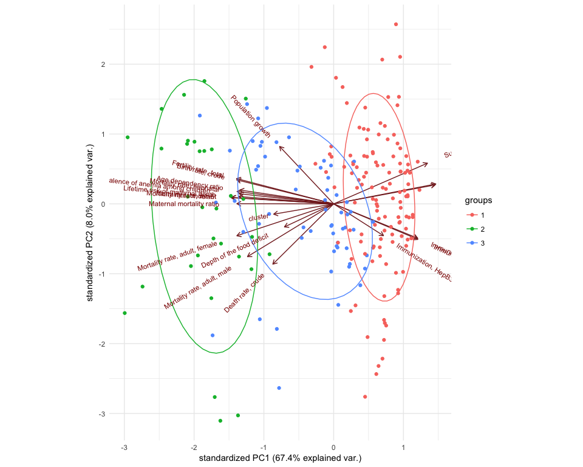

```r
health.cluster.pca = prcomp(all.health.clusters %>% dplyr::select(-country), center = T, scale. = T)
ggbiplot(health.cluster.pca,
         groups = as.factor(kcl.health$cluster), ellipse = T) +
  theme_minimal()
```

## 8.2 Education

### 8.2.1 Q5

[interactive chart not shown]

### 8.2.2 Q6

#### 8.2.2.1 Replacing NAs

```r
all.edu.clusters <- all.edu %>%
  dplyr::group_by(country) %>% sapply(as.numeric) %>% na.aggregate() %>% as.data.frame()


all.edu.clusters$country <- all.edu$country

all.edu.clusters <- all.edu.clusters %>%
  dplyr::select(-year) %>%
  dplyr::group_by(country) %>%
  dplyr::summarise_all(funs(mean))
```

#### 8.2.2.2 Cluster Analysis by K-means

```r
kcl.edu <- kmeans(all.edu.clusters %>% dplyr::select(-country), centers = 3)

all.edu.clusters$cluster <- kcl.edu$cluster
kcl.edu
```

```
K-means clustering with 3 clusters of sizes 10, 197, 2

Cluster means:
  School enrollment, primary School enrollment, secondary
1                   103.9586                     80.14903
2                   101.7752                     78.06251
3                   104.8201                     68.50307
  Primary completion rate, total
1                       91.24129
2                       87.00648
3                       89.37259
  Government expenditure on education, total
1                                   3.965144
2                                   4.568561
3                                   4.147772
  Government expenditure per student, tertiary
1                                     3.965144
2                                     4.568561
3                                     4.147772
  Government expenditure per student, secondary
1                                      18.83573
2                                      21.13959
3                                      20.09035
  Government expenditure per student, primary
1                                    15.29698
2                                    15.77226
3                                    14.35280
  Pupil-teacher ratio, tertiary Pupil-teacher ratio, primary
1                      15.39579                     23.60070
2                      16.69470                     25.51980
3                      18.44565                     25.72668
  Secondary education, vocational pupils
1                              1099881.9
2                               251450.5
3                              6504204.0
  Secondary education, general pupils Secondary education, pupils
1                            11045538                    11622721
2                             1362012                     1745642
3                            60466503                    82068631
  Secondary education, duration Lower secondary school starting age
```

[output cut: 18 more lines]

```
 [36] 2 2 2 2 2 3 2 2 2 2 2 2 2 2 2 2 2 2 2 2 2 2 2 2 2 2 2 2 2 2 2 2 2 2 2
 [71] 1 2 2 2 2 2 2 2 2 2 2 2 2 2 3 1 1 2 2 2 2 2 1 2 2 2 2 2 2 2 2 2 2 2 2
[106] 2 2 2 2 2 2 2 2 2 2 2 2 2 2 2 2 1 2 2 2 2 2 2 2 2 2 2 2 2 2 2 2 2 2 2
[141] 2 1 2 2 2 2 2 2 2 2 2 2 2 1 2 2 2 2 2 2 2 2 2 2 2 2 2 2 2 2 2 2 2 2 2
[176] 2 2 2 2 2 2 2 2 2 2 2 2 2 2 2 2 2 2 2 2 2 2 2 1 2 2 2 2 2 2 2 2 2 2

Within cluster sum of squares by cluster:
[1] 5.557329e+14 5.926004e+14 2.786484e+14
 (between_SS / total_SS =  93.7 %)

Available components:

[1] "cluster"      "centers"      "totss"        "withinss"
[5] "tot.withinss" "betweenss"    "size"         "iter"
[9] "ifault"
```

#### 8.2.2.3 Iran’s cluster

```r
iran.edu.cluster <- all.edu.clusters %>% dplyr::filter(country %>% str_detect("Iran"))
all.edu.clusters %>% dplyr::select(country, cluster) %>% dplyr::filter(cluster == iran.edu.cluster$cluster) %>%
  knitr::kable(format = "html") %>% kable_styling(bootstrap_options = c("striped", "hover"), full_width = F, position = "left")
```

| country | cluster |
| --- | --- |
| Bangladesh | 1 |
| Brazil | 1 |
| Germany | 1 |
| Indonesia | 1 |
| Iran, Islamic Rep. | 1 |
| Japan | 1 |
| Mexico | 1 |
| Pakistan | 1 |
| Russian Federation | 1 |
| United States | 1 |

### 8.2.3 Testing The Clusters Using PCA

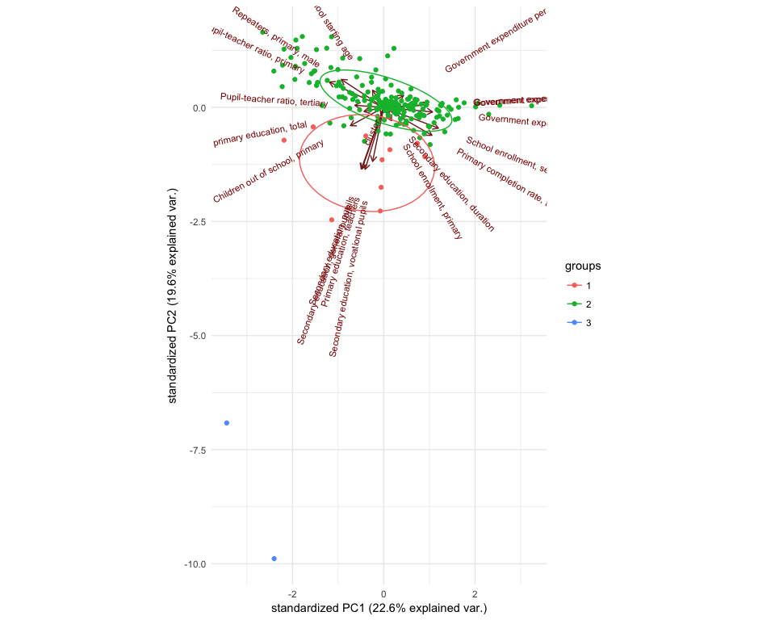

```r
edu.cluster.pca = prcomp(all.edu.clusters %>% dplyr::select(-country), center = T, scale. = T)
ggbiplot(edu.cluster.pca,
         groups = as.factor(kcl.edu$cluster), ellipse = T) +
  theme_minimal()
```

If we remove the NAs we will also get a similar result:

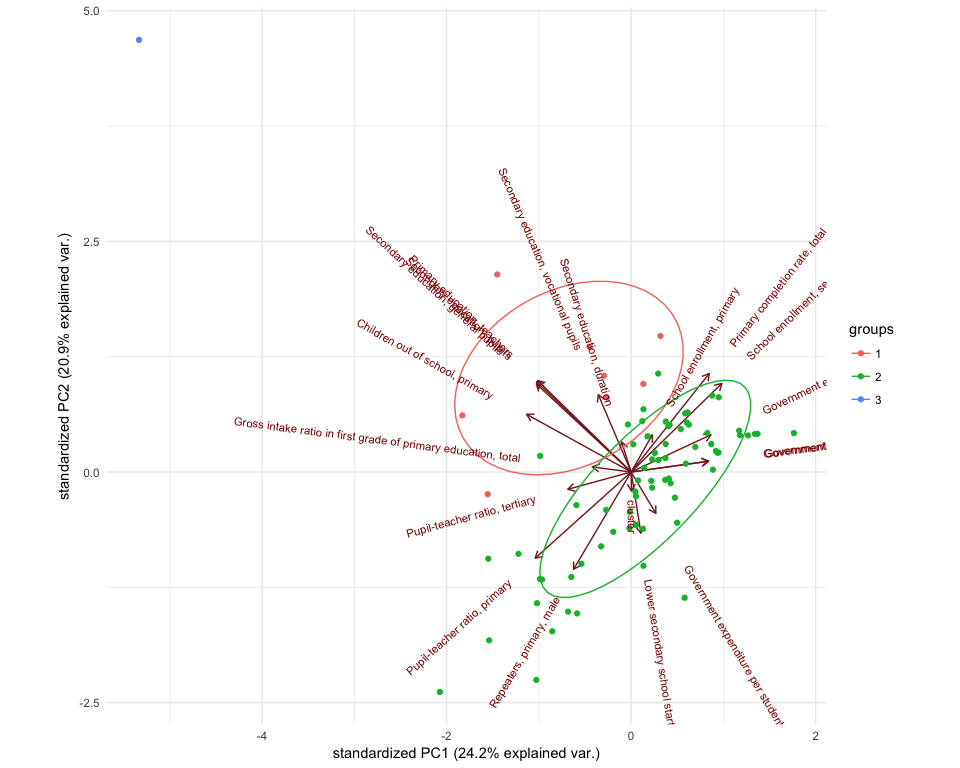

# 9 Cluster Analysis Using Hierarchical Models

## 9.1 Joining and Replacing NAs

```r
final <- all.econ %>% full_join(all.health) %>% full_join(all.edu)

final.clusters <- final %>% dplyr::select(-country) %>% sapply(as.numeric) %>% na.aggregate() %>% as.data.frame()
final.clusters$country <- final$country

final.clusters <- final.clusters %>%
  dplyr::select(-year) %>%
  dplyr::group_by(country) %>%
  dplyr::summarise_all(funs(mean))

rownames(final.clusters) <- final.clusters$country
```

## 9.2 Drawing The Dendrogram

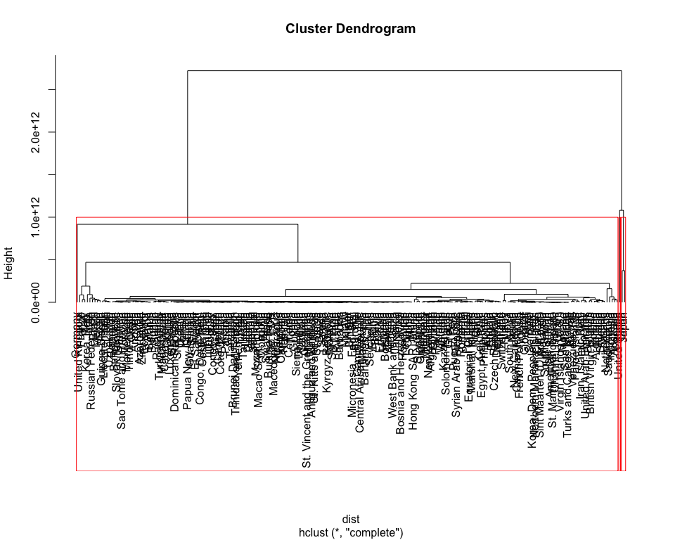

```r
dist = stats::dist(final.clusters,method = "euclidean")
clus = hclust(dist,method = "complete")

plot.new()
plot(clus,hang = -1)
rect.hclust(clus, k = 3)
```

### 9.2.1 Sampling The Data

```r
final.iran <- final.clusters %>%
  dplyr::filter(country %>% str_detect("Iran"))
final.world <- final.clusters %>%
  dplyr::filter(!(country %>% str_detect("Iran"))) %>%
  sample_frac(0.1)
final.sample <- rbind(final.iran, final.world)
```

### 9.2.2 Drawing The Dendrogram

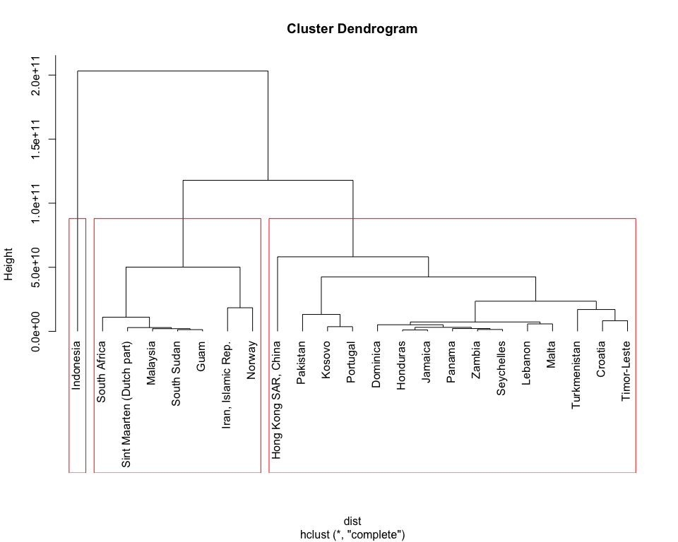

```r
rownames(final.sample) <- final.sample$country
dist = stats::dist(final.sample, method = "euclidean")
clus = hclust(dist,method = "complete")

plot.new()
plot(clus,hang = -1)
rect.hclust(clus, k = 3)
```

# 10 Three Interesting Facts

## 10.1 The Deadliest Year in History

> Indicator Used: Population, total

For each country, I have computed the change in population in each year:

```r
data.pop.dif <- data.pop %>%
  group_by(`Country Name`) %>%
  arrange(`Country Name`, year) %>%
  mutate(dif = population - lag(population)) %>%
  dplyr::mutate(temp = row_number()) %>% filter(temp != 1) %>% select(-temp)
```

Now I’ve calculated the average of change in each year for every country, and drawn the plot:

[interactive chart not shown]

Now, without further ado, the deadliest year of since 1960 is:

| Country Name | year | dif |
| --- | --- | --- |
| China | 1961 | -6740000 |

A whooping almost 7 million people died.

The average life expectancy of the world in 1961 was:

```
[1] 53.91972
```

While the life expectancy of China was:

| country | year | SP.DYN.LE00.IN |
| --- | --- | --- |
| China | 1961 | 44.051 |

What happened this year that killed so many people was the **Great Chinese Famine**.

## 10.2 The Deadliest War

> Indicator Used: Battle-related deaths (number of people)

Since we’re still on the subject of death and depression, I’ve computed the number of deaths in battles.

The most peaceful year was:

| Country Name | year | deaths |
| --- | --- | --- |
| Serbia | 2001 | 0 |

Way to go Serbia.

The most distressful year was:

| Country Name | year | deaths |
| --- | --- | --- |
| Syrian Arab Republic | 2013 | 69086 |

Which is not surprising at all.

## 10.3 Iran’s Decline in Economics

All everyone can discuss and complain about for the past few years is how much we used to be on top of the world, and sadly we’re not anymore.  
First of all, I’d like to test whether inflation in Iran grows with each passing year or not.

```
    Pearson's product-moment correlation

data:  inflation.iran$year and inflation.iran$inflation
t = 4.4802, df = 55, p-value = 3.816e-05
alternative hypothesis: true correlation is not equal to 0
95 percent confidence interval:
 0.2964545 0.6853123
sample estimates:
      cor
0.5170796
```

Based on the results of the correlation test, it seems that inflation does kind of increase each year.

To feel slightly better about ourselves, let’s take a look at the highest values:

| Country Name | year | inflation |
| --- | --- | --- |
| Zimbabwe | 2007 | 24411.031 |
| Congo, Dem. Rep. | 1994 | 23773.132 |
| Bolivia | 1985 | 11749.640 |
| Nicaragua | 1988 | 10205.027 |
| Nicaragua | 1990 | 7485.492 |
| Peru | 1990 | 7481.664 |
| Nicaragua | 1989 | 4770.190 |
| Ukraine | 1993 | 4734.914 |
| Angola | 1996 | 4145.108 |
| Congo, Dem. Rep. | 1992 | 4129.170 |

But not so fast. Let’s take a look at the closest year afterwards that we have records of:

| Country Name | year | inflation |
| --- | --- | --- |
| Zimbabwe | 2010 | 3.034479 |

Talk about a comeback.

Now let’s dive back into depression and draw the chart for Iran:

[interactive chart not shown]

2013 was the year of our lord and saviour president Rouhani, with an inflation of 39%. #Rouhani_Mochakerim